# s01 — variant read-fate panel (direct per-SNP visibility, iter1→2→3)

gwct

10/28/2026 10:29 EDT

```r
knitr::opts_chunk$set(echo = TRUE, warning = FALSE, message = FALSE, fig.align = "center")
library(ggplot2); library(dplyr); library(tidyr); library(readr); library(ggalluvial)
source("analyses/lib/design.r")
```

**Provenance**

- **Rendered from commit** `12452f63e370` (branch `mason2-sims`) on 2026-10-28 10:29
- **This notebook:** notebook as committed
- **Analysis code:** no uncommitted edits under `analyses/`
- Each data file’s producing script and command: the section’s `MANIFEST.yaml`

This is the full panel of the per-variant read-fate flow, split into **separate large plots** (one per caller × divergence) so each is legible. It uses the **direct per-SNP visibility** measure, not the read’s dominant class: each SNP is labeled by the plurality state of its covering reads —

- **visible** — the SNP’s own reference position is aligned in the read (base presented to the caller)
- **clipped/del** — read at the right locus but the SNP position is soft-clipped over or deleted (base *not* presented at its coordinate)
- **mismapped** — read placed at the wrong locus
- **unmapped**

Restricted to the SNPs each caller **newly recovers by iteration 3**, traced across iterations 1 → 2 → 3. The flow into *visible* is recovery via better alignment; a *visible → visible* band is a SNP whose base was already presented but the caller (gatk’s reassembler) missed anyway until effective divergence fell.

```r
pcl   <- c("p_visible", "p_clipdel", "p_mismap", "p_unmap")
pnice <- c(p_visible = "visible", p_clipdel = "clipped/del", p_mismap = "mismapped", p_unmap = "unmapped")
pcols <- c(visible = "#009E73", `clipped/del` = "#E69F00", mismapped = "#D55E00", unmapped = "#999999")
plev  <- names(pcols)

vf <- bind_rows(lapply(c("0.04","0.06","0.08","0.10"), function(d)
  read_csv(sprintf("analyses/s01-baseline-iterative/results/s01-varfate-%s.csv", d),
           col_types = cols()))) %>%
  mutate(divergence = as.numeric(divergence),
         # per-SNP visibility from the read ledger (variant_read_fate.py; columns in the tables'
         # dictionaries): reads at the locus (exact or shifted start) that present a base at the SNP,
         # reads at the locus with the SNP soft-clipped or deleted, reads placed elsewhere, unmapped
         p_visible = ex_alt + ex_ref + ex_err + sh_alt + sh_ref + sh_err,
         p_clipdel = ex_clip + ex_del + sh_clip + sh_del,
         p_mismap  = mm_clip + mm_noclip + dc,
         p_unmap   = un)
traj <- vf %>% group_by(caller, divergence, snp_pos) %>%
  summarize(r1 = recovered[iteration == 1], r3 = recovered[iteration == 3], .groups = "drop") %>%
  mutate(new = r1 == 0 & r3 == 1)
vf <- vf %>% left_join(select(traj, caller, divergence, snp_pos, new),
                       by = c("caller", "divergence", "snp_pos"))
vf$pdom <- factor(pnice[pcl[max.col(as.matrix(vf[, pcl]), ties.method = "first")]], levels = plev)

flow3 <- function(cc, dd) {
  vf %>% filter(caller == cc, divergence == dd, new, n_reads > 0) %>%
    select(snp_pos, iteration, pdom) %>%
    pivot_wider(names_from = iteration, values_from = pdom) %>%
    rename(i1 = `1`, i2 = `2`, i3 = `3`) %>% filter(!is.na(i1), !is.na(i2), !is.na(i3)) %>%
    count(i1, i2, i3, name = "nsnp")
}
```

```r
for (cc in c("gatk", "bcftools", "freebayes")) {
  cat(sprintf("\n\n# %s\n\n", cc))
  for (dd in c(0.04, 0.06, 0.08, 0.10)) {
    w3 <- flow3(cc, dd)
    cat(sprintf("\n\n## %s — D = %s  (%d newly-recovered SNPs)\n\n", cc, format(dd), sum(w3$nsnp)))
    if (nrow(w3) == 0 || sum(w3$nsnp) == 0) { cat("_none_\n\n"); next }
    p <- ggplot(w3, aes(axis1 = i1, axis2 = i2, axis3 = i3, y = nsnp)) +
      geom_alluvium(aes(fill = i1), alpha = 0.85) +
      geom_stratum(width = 0.3, fill = "grey92", color = "grey55") +
      geom_text(stat = "stratum", size = 3,
                aes(label = ifelse(after_stat(count) >= max(3, 0.03 * sum(w3$nsnp)),
                                   as.character(after_stat(stratum)), ""))) +
      scale_x_discrete(limits = c("iter1", "iter2", "iter3"), expand = c(0.06, 0.06)) +
      scale_fill_manual(values = pcols, name = "iter1 state", drop = FALSE) +
      labs(x = NULL, y = "newly-recovered SNPs",
           title = sprintf("%s, D = %s — per-SNP base visibility across iterations", cc, format(dd))) +
      bartheme()
    print(p)
    cat("\n\n")
  }
}
```

# gatk

## gatk — D = 0.04 (174 newly-recovered SNPs)

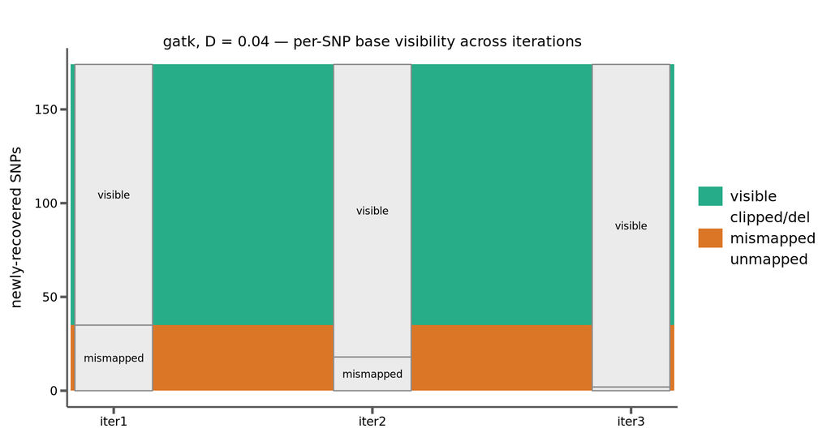

## gatk — D = 0.06 (274 newly-recovered SNPs)

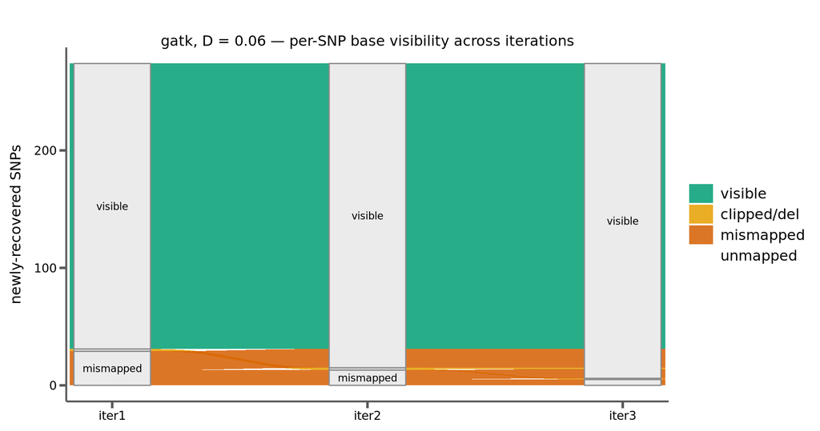

## gatk — D = 0.08 (546 newly-recovered SNPs)

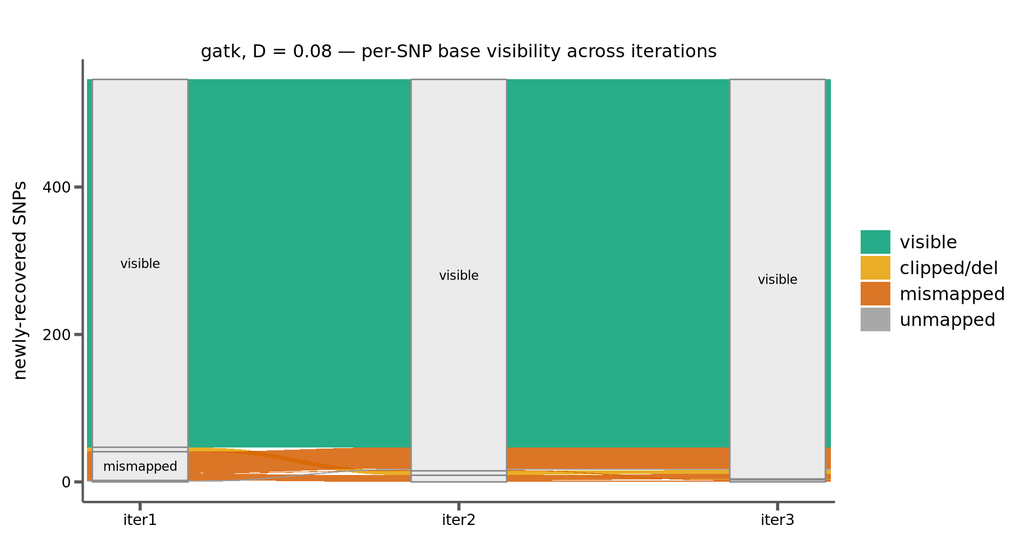

## gatk — D = 0.1 (822 newly-recovered SNPs)

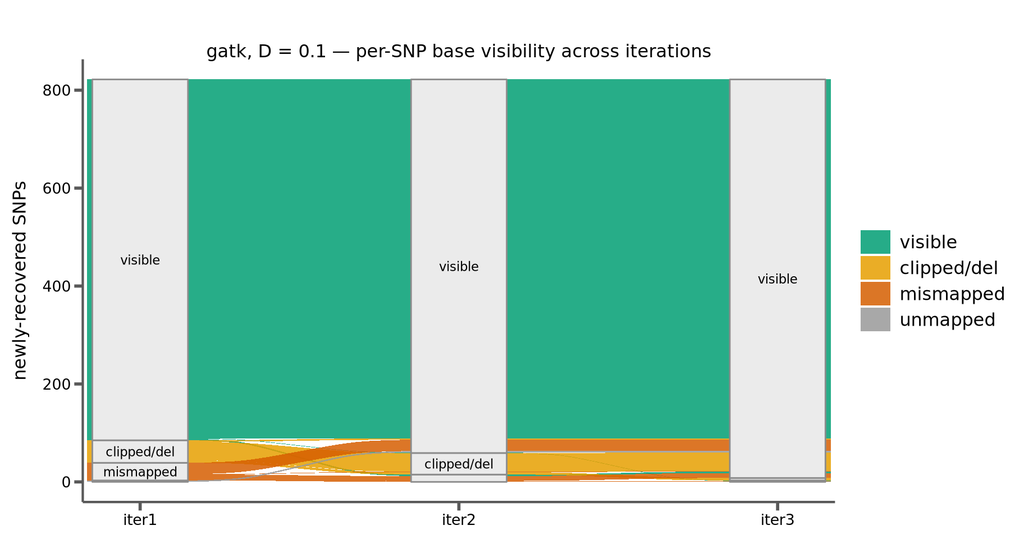

# bcftools

## bcftools — D = 0.04 (47 newly-recovered SNPs)

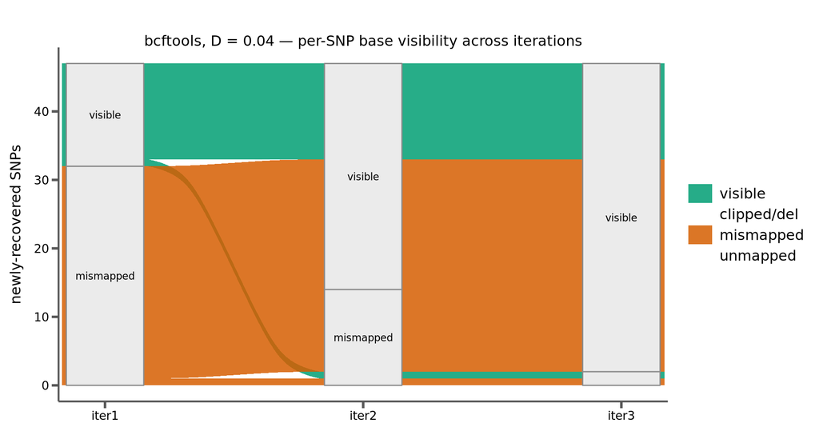

## bcftools — D = 0.06 (46 newly-recovered SNPs)

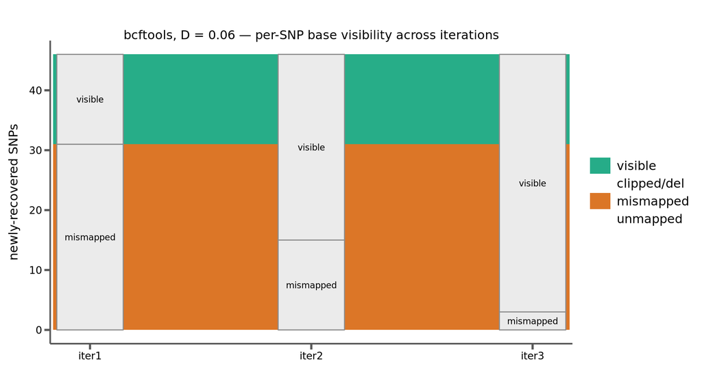

## bcftools — D = 0.08 (78 newly-recovered SNPs)

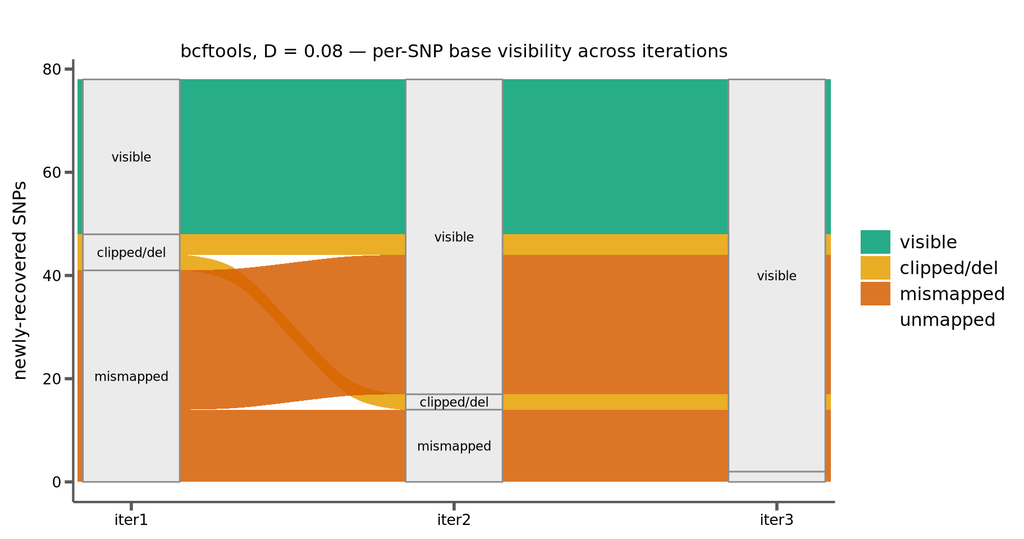

## bcftools — D = 0.1 (136 newly-recovered SNPs)

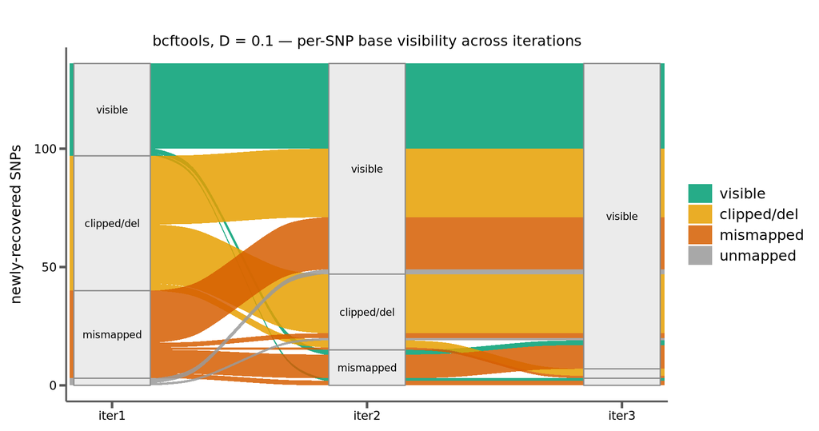

# freebayes

## freebayes — D = 0.04 (50 newly-recovered SNPs)

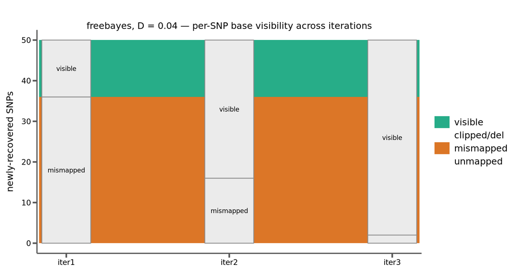

## freebayes — D = 0.06 (42 newly-recovered SNPs)

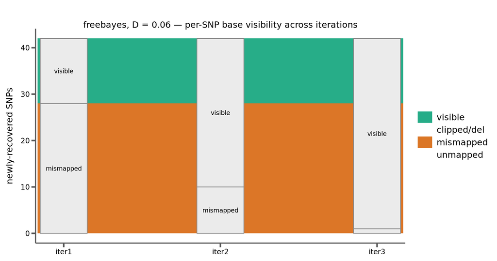

## freebayes — D = 0.08 (76 newly-recovered SNPs)

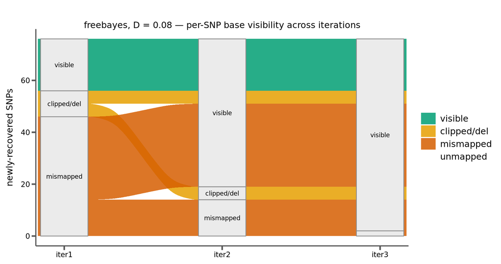

## freebayes — D = 0.1 (142 newly-recovered SNPs)

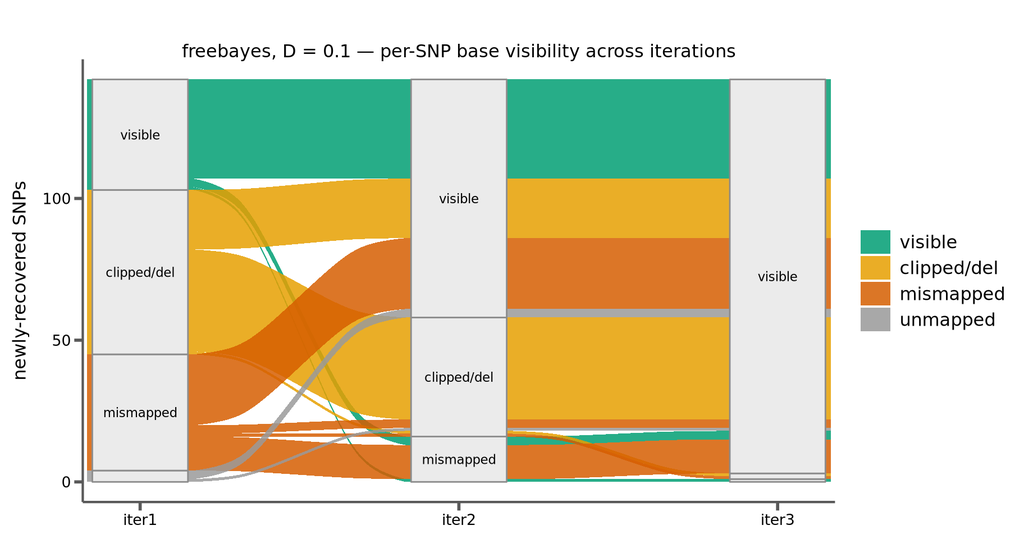